# Curso PostgreSQL

[figure not shown]

**Autor: Luis Fernando Apáez Álvarez**  
-Curso PyM-  
Clase 2: Modificando una tabla, lenguajes DDL y DML.  
Fecha: Marzo del 2023

En la clase pasada vimos la sintaxis para crear una tabla, la cual, básicamente, es

```
CREATE TABLE <<nombre de la tabla>>(
    <<nombre columna 1>> <<tipo de dato>>,
    <<nombre columna 2>> <<tipo de dato>>,
    .
    .
    .
    <<nombre columna n>> <<tipo de dato>>
);
```

Para esta clase crearemos una tabla de prueba, la cual será posteriormente eliminada. Así, usamos

```
CREATE TABLE prueba(
    id_prueba SERIAL,
    nombre_prueba VARCHAR,
    fecha DATE
);
```

la cual, como ya sabemos, se mostrará dentro del esquema público en la parte de *Tables*

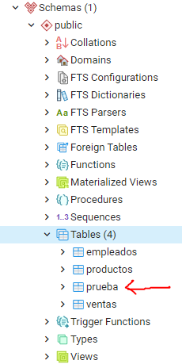

##### Nota

Los bloques de código que colocamos como:

```
-- este es un bloque de código
```

en las clases harán referencia directa código que se escribe en el *Query tool* de *pgAdmin*. Esto es, si nosotros escribimos algo como

```
SELECT * FROM productos;
```

ese mismo código es el que debes escribir en el *Query tool* de tu *pgAdmin*.

Una vez creada nuestra tabla de prueba procedemos a eliminarla, lo cual se consigue con la siguiente sintaxis

```
DROP TABLE prueba;
```

donde la ejecución ha sido exitosa

Luego, puede que sigamos viendo la tabla dentro del esquema público. Para actualizarlo damos click derecho en *public* y después click en *Refresh*

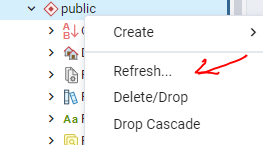

con lo cual deberías de conseguir que las únicas tablas que se muestran son las que creamos la clase pasada

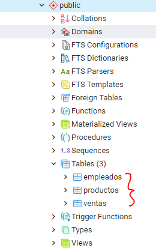

Otra alternativa para eliminar una tabla es ir directamente a ella en el esquema público y pulsar click derecho, después seleccionamos la opción que dice *Delete/Drop*

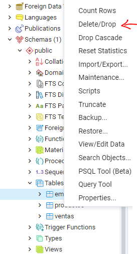

Así, tendremos dos opciones cuando queramos eliminar una tabla: una, utilizando código SQL y la otra yendo a las opciones que nos brinda *pgAdmin* al dar click derecho en la tabla en cuestión.

De hecho, para eliminar una base de datos procederíamos a ir a dicha base y pulsar click derecho, después seleccionaríamos la opción *Delete/Drop*.

[figure not shown]

#### Modificación de una tabla

Supongamos que en la tabla `empleados`

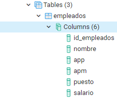

olvidamos colocar la columna `horario`. Si bien podríamos eliminar dicha tabla y después volverla a crear agregando la columna que nos faltó, este método después sería inconcebible pues imaginemos que dicha tabla cuenta ya con mil filas, entonces al eliminar la tabla perderíamos toda la información.

Para **modificar una tabla y agregar una columna** nueva utilizamos la siguiente sintaxis

```
ALTER TABLE <<nombre tabla>> ADD COLUMN <<nombre columna nueva>> <<tipo de dato>>;
```

Así, para agregar la columna `horario` a la tabla `empleados` escribimos

```
ALTER TABLE empleados ADD COLUMN horario VARCHAR;
```

Para ver los cambios, como ya sabemos, vamos a la tabla `empleados` y damos click derecho, después pulsamos `Refresh`, con lo cual deberíamos de ver

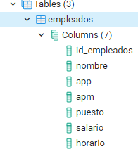

ya la columna `horario`.

Podemos **eliminar** también **columnas** de una tabla. Para ejemplificar la eliminación de una columna, agregaremos primero otra columna nueva a la tabla `empleados`

```
ALTER TABLE empleados ADD COLUMN prueba DATE;
```

Así, eliminamos esta última columna escribiendo

```
ALTER TABLE empleados DROP COLUMN prueba;
```

Luego, podemos **cambiar el nombre** tanto de las tablas como de las columnas. Para cambiar el nombre de las tablas empleamos

```
ALTER TABLE <<nombre tabla>> RENAME TO <<nuevo nombre tabla>>;
```

y para cambiar el nombre de una columna

```
ALTER TABLE <<nombre tabla>> RENAME COLUMN <<nombre columna>> TO <<nuevo nombre columna>>;
```

Finalmente, podemos **cambiar el tipo de dato de una columna**. Esto no es recomendable hacerlo después, pues imaginemos que en la tabla `empleados` en la columna `salario` tenemos entradas como 8500.0, 15,250.80, etcétera; después, si cambiamos el tipo de dato de `salario` de `REAL` a `INT` (por ejemplo) entonces *postgres* nos marcará un error. Así, si deseamos cambiar el tipo de dato de una columna, lo mejor es hacerlo en estas instancias en las que no hemos ingresado información a nuestras tablas. Además, es preciso mencionar que siempre debemos planificar bien la estructura de nuestras bases de datos, algo así a lo que hicimos en la clase pasada donde primero describimos brevemente cada columna de la tabla `productos` e incluimos el tipo de dato que le asignaríamos a cada una.

Ahora, para cambiar el tipo de dato de una columna utilizamos la siguiente sintaxis

```
ALTER TABLE <<nombre tabla>> ALTER COLUMN <<nombre columna>> SET DATA TYPE <<tipo de dato>>;
```

Con el código anterior seguramente tendremos problemas a la hora de intentar cambiar el tipo de dato de una columna que almacena cadenas de texto a un tipo de dato numérico (por ejemplo al tipo de dato `int`). Para realizar dicho cambio, escribiremos el código

```
ALTER TABLE <<nombre tabla>>s ALTER COLUMN <<nombre columna>> TYPE INT USING <<nombre columna>>::INTEGER;
```

#### Lenguaje de definición de datos (DDL: *Data Definition Languaje*)

Dentro del lenguaje SQL tenemos un sublenguaje denominado DDL el cual nos permite **definir** estructuras que almacenarán datos, así como funciones que permitan consultarlos. Las sentencias que ocupamos en el DDL son:

`CREATE`: Lo utilizamos para crear bases de datos, tablas, funciones, vistas, etcétera.

`ALTER`: Lo utilizamos para modificar la estructura. Por ejemplo añadir o modificar columnas, cambiar el nombre de tablas o columnas, etcétera.

`DROP`: Nos permite eliminar objetos de la estructura. Por ejemplo, podemos eliminar bases de datos o tablas.

Así, si nos damos cuenta, hasta ahora en nuestras clases hemos estado utilizando el *lenguaje de definición de datos* en nuestro código sql.

Existen varios tipos de sublenguajes como el DDL, en esta clase sólo abordaremos otro sublenguaje el cual es:

#### Lenguaje de manipulación de datos (DML: *Data Manipulation Languaje*)

Como bien dice el nombre, este sublenguaje se utiliza para manipular los datos de nuestra base de datos. Podemos consultar nuestros datos, insertar datos nuevos a las tablas, modificar los valores de los datos ya ingresados y también borrarlos. De tal manera, en el lenguaje DML utilizamos las sentencias

`SELECT`: nos permite realizar consultas de nuestros datos.

`INSERT`: nos permite insertar valores a nuestra base de datos (BD).

`UPDATE`: nos permite modificar los datos ya ingresados en la BD.

`DELETE`: nos permite eliminar filas de las tablas de la BD.

En esta clase trabajaremos con cada una de las sentencias mencionadas anteriormente.

##### Inserciones de datos

Comenzaremos por ingresar información a nuestra base de datos. Para ello comenzaremos por ingresar la información en la tabla empleados. Para ello debemos saber bien cuáles son las columnas que la conforman y el tipo de dato que aceptan, pues si ingresamos (por ejemplo) un número real en una columna que admite enteros entonces *postgres* nos marcará error.

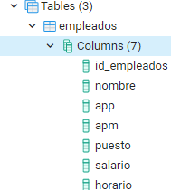

Por consiguiente, ingresaremos la información de un primer empleado utilizando el siguiente código

```
INSERT INTO empleados(nombre, app, apm, puesto, salario, horario) VALUES ('Luis', 'Apáez', 'Álvarez', 'Cajero', 8500.0, '6:00-14:00');
```

recordemos que las cadenas de texto, en particular del tipo `varchar`, deben ir entre comillas simples; además, recordemos que la columna horario acepta datos del tipo cadena de texto, por ello el horario lo hemos colocado entre comillas simples, además el salario es de tipo `real`, por ello colocamos 8500.0.

Notemos que donde colocamos el nombre de las columnas `empleados(nombre, app, apm, puesto, salario, horario)`, omitimos la columna `id_empleados` pues el tipo de dato con el cual la definimos es `serial` el cual es un incremento automático partiendo del uno, es decir, el `id_empleados` igual a 1 le corresponde al empleado que acabamos de registrar. Si registramos la información de otro empleado, entonces su `id_empleados` será el número 2 y así consecutivamente.

De tal manera, la sintaxis general para ingresar datos a nuestras tablas es la siguiente:

```
INSERT INTO <<nombre tabla>> (<<columna 1>>, <<columna 2>>,..., <<columna n>>) VALUES
(<<valor columnas 1>>, <<valor columna 2>>,...,<<valor columna n>>);
```

Asimismo, podemos ingresar información solo en algunas columnas de una tabla. Por ejemplo, pudimos haber ingresado sólo el nombre del empleado en la tabla `empleados` escribiendo

```
INSERT INTO empleados(nombre) VALUES ('Luis');
```

o solo ingresar un salario en una fila de la tabla, sin especificar otra cosa

```
INSERT INTO empleados(salario) VALUES (4500.5);
```

Recapitulando, hasta el momento sólo hemos ingresado un empleado a nuestra tabla `empleados`. Para ver la información que hemos ingresado en esta tabla haremos uso de las **consultas**. Para los fines de este tema sólo veremos la consulta más sencilla de todas, la cual nos permite ver toda la informuación de nuestra tabla. Para efectuar una consulta que nos arroje toda la información de la tabla escribimos

```
SELECT * FROM <<nombre de la tabla>>;
```

De tal manera, en nuestro caso escribimos

```
SELECT * FROM empleados;
```

lo cual nos arroja al ejecutarlo lo siguiente:

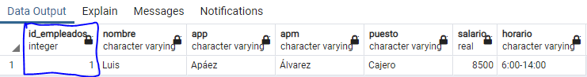

donde puede verse que en automático se ha puesto el número 1 en el `id_empleados`, además podemos ver los nombres de las columnas y el tipo de dato que admiten de acuerdo a cómo definimos las columnas.

Ahora, ingresemos el siguiente empleado omitiendo algunas columnas

```
INSERT INTO empleados(nombre, app, apm, horario) VALUES ('Zed', 'Ocaña', 'López', '6:00-13:00');

-- Después realizamos nuevamente una consulta
SELECT * FROM empleados;
```

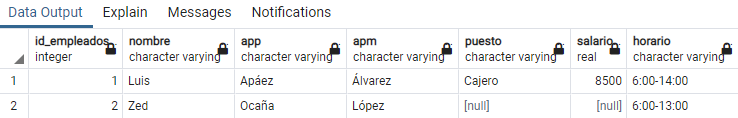

donde puede verse que en las columnas donde no ingresamos información se ha colocado en automático la etiqueta `null`. En muchas ocasiones, tener valores nulos no es lo más óptimo en una base de datos, en algunos otros casos no hay otra alternativa. Como en nuestro caso, el tener el registro de un empleado sin tener especificado el puesto que cubre no puede ocurrir, entonces ingresaremos la información que nos falta referente al empleado Zed. Para ello haremos uso de la sentencia `UPDATE`, la cual nos permitirá actualizar información en nuestras tablas. La sintaxis básica es

```
UPDATE <<nombre tabla>> SET <<nombre columna>> = <<valor correspondiente>> WHERE <<condición>>;
```

En nuestro caso queremos cambiar los valores nulos de las columnas `puesto` y `salario` referente al empleado Zed (cuyo `id_empleados` es igual a 2), donde pondremos en su lugar `Vigilante` y `12500.5` respectivamente. Para ello

- Opción 1:

```
UPDATE empleados SET puesto = 'Vigilante' WHERE id_empleados = 2;
```

estamos colocando en la columna `puesto` el valor `'Viglante'` en el empleado cuyo `id_empleados` es igual a 2, es decir, estamos actualizando la información de Zed. También, en vez de utilizar al final `WHERE id_empleados = 2` pudimos haber utilizado `WHERE nombre = 'Zed'`, sin embargo, si en nuestra tabla tuviéramos dos empleados con el mismo nombre entonces tendríamos un problema. De ahí la importancia de tener un identificador único en cada tabla, que en este caso es el `id_empleados`. Procedemos a agregar también el salario

```
UPDATE empleados SET salario = 12500.5 WHERE id_empleados = 2;
```

- Opción 2 (recomendable):

En vez de realizar dos `UPDATES` podemos simplemente efectuar uno en la misma sentencia colocando una coma de separación entre cada columna, esto es

```
UPDATE empleados SET puesto = 'Vigilante', salario = 12500.5 WHERE id_empleados = 2;
```

o de manera más estética podemos escribir lo anterior como

```
UPDATE empleados
SET puesto = 'Vigilante',
    salario = 12500.5
WHERE id_empleados = 2;
```

y realizamos una consulta para ver los cambios

```
SELECT * FROM empleados;
```

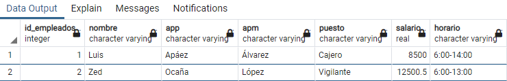

donde ya no tenemos los valores nulos que teníamos antes.

Continuando, ingresemos el siguiente "empleado":

```
INSERT INTO empleados(nombre, app, apm, puesto, salario, horario)
    VALUES('ññ', 'ñ', 'uwu', 'ñe', 2.5, 'ññ')
```

la cual no tiene ningún sentido pero nos ayudará a utilizar la sentencia `DELETE`. Una vez que consultamos la tabla

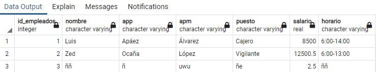

procedemos a eliminar la fila 3 con los datos que no tienen sentido, para ello escribimos

```
-- Recordemos que queremos eliminar la fila 3
DELETE FROM empleados WHERE id_empleados = 3;
```

y después consultamos para ver que la fila 3 ya no está en la tabla `empleados`

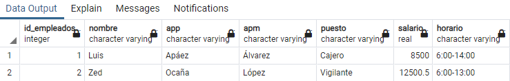

En conjunto ya hemos abordado las 4 sentencias de las que hablamos sobre el *lenguaje de manipulación de datos (DML)*.